# The making-of the figures in the article

Herein we provide the full code to realize Figures 1 to 4 that illustrate the article describing the `superb` framework (Cousineau, Goulet, & Harding, 2021). These figures are based on ficticious data sets that are provided with the package superb (`dataFigure1` to `dataFigure4`).

Before we begin, we need to load a few packages, including `superb` of course:

```r
## Load relevant packages
library(superb)             # for superbPlot
library(ggplot2)            # for all the graphic directives
library(gridExtra)          # for grid.arrange
```

If they are not present on your computer, first upload them to your computer with `install.packages("name of the package")`.

# Making Figure 1

The purpose of Figure 1 is to illustrate the difference in error bars when the purpose of these measures of precision is to perform pair-wise comparisons. It is based on the data from `dataFigure1`, whose columns are

```r
head(dataFigure1)
```

```
##   id grp score
## 1  1   1   117
## 2  2   1   103
## 3  3   1   113
## 4  4   1   101
## 5  5   1   104
## 6  6   1   114
```

where `id` is just a participant identifier, `grp` indicate group membership (here only group 1 and group 2), and finally, `score` is the dependent variable.

The first panel on the left is based on stand-alone confidence intervals and is obtained with :

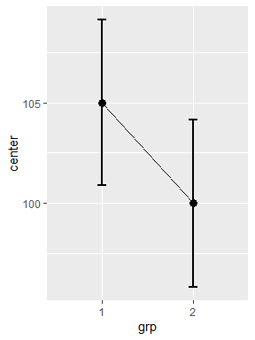

**Figure 1a**. Left panel of Figure 1.

```r
plt1a <- superb( score ~ grp,
            dataFigure1,
            plotStyle   = "line" )
plt1a
```

Note that these *stand-alone* error bars could have been obtained by adding the argument `adjustments = list(purpose = "single")` but as it is the default value, it can be omitted.

The default `theme` to `ggplot`s is not very attractive. Let’s decorate the plot a bit! To that end, I collected some additional ggplot directives in a list:

```r
ornateBS <- list(
    xlab("Group"),
    ylab("Attitude towards class activities"),
    scale_x_discrete(labels = c("Collaborative\ngames", "Unstructured\nactivities")), #new!
    coord_cartesian( ylim = c(70,130) ),
    geom_hline(yintercept = 100, colour = "black", linewidth = 0.5, linetype=2),
    theme_light(base_size = 10) +
    theme( plot.subtitle = element_text(size=12))
)
```

so that the first plot, with these ornaments and a title, is:

```r
plt1a <- plt1a + ornateBS + labs(subtitle="(stand-alone)\n95% CI")
plt1a
```

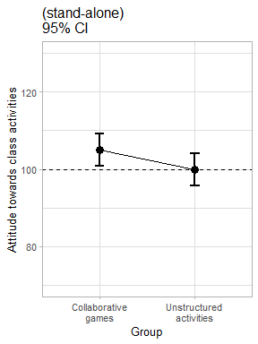

**Figure 1b**. Decorating left panel of Figure 1.

The second plot is obtained in a simar fashion with just one additional argument requesting difference-adjusted confidence intervals:

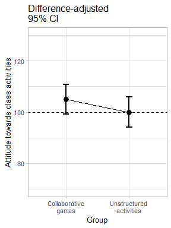

**Figure 1c**. Making and decorating central panel of Figure 1.

```r
plt1b <- superb( score ~ grp,
            dataFigure1,
            adjustments  = list(purpose = "difference"), #new!
            plotStyle    = "line" )
plt1b <- plt1b + ornateBS + labs(subtitle="Difference-adjusted\n95% CI")
plt1b
```

Finally, the *raincloud* plot is obtained by changing the `plotStyle` argument:

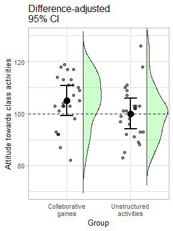

**Figure 1d**. Making and decorating right panel of Figure 1.

```r
plt1c <- superb(
            score ~ grp,
            dataFigure1,
            adjustments  = list(purpose = "difference"),
            plotStyle    = "raincloud",                         # new layout!
            violinParams = list(fill = "green", alpha = 0.2) ) # changed color to the violin
plt1c <- plt1c + ornateBS + labs(subtitle="Difference-adjusted\n95% CI")
plt1c
```

All three plots are shown side-by-side with:

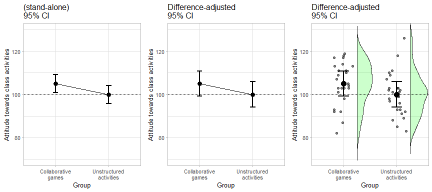

**Figure 1**. The complete Figure 1.

```r
grid.arrange(plt1a, plt1b, plt1c, ncol=3)
```

and exported to a file, with, e.g.:

```r
png(filename = "Figure1.png", width = 640, height = 320)
grid.arrange(plt1a, plt1b, plt1c, ncol=3)
dev.off()
```

You can change the smooth density estimator (the `kernel` function) by adding to the `violinParams` list the following attribute: `kernel = "rectangular"` for example to have a ragged density estimator.

Still not convinced? Let’s do a *t* test (actually, a Welch test; add `var.equal = TRUE` for the regular *t* test; Delacre, Lakens, & Leys (2017)):

```r
t.test(dataFigure1$score[dataFigure1$grp==1],
       dataFigure1$score[dataFigure1$grp==2],
       )
```

```
##
##  Welch Two Sample t-test
##
## data:  dataFigure1$score[dataFigure1$grp == 1] and dataFigure1$score[dataFigure1$grp == 2]
## t = 1.7612, df = 47.996, p-value = 0.08458
## alternative hypothesis: true difference in means is not equal to 0
## 95 percent confidence interval:
##  -0.7082323 10.7082323
## sample estimates:
## mean of x mean of y
##       105       100
```

There are no significant difference in these data at the .05 level, so that the error bar of a 95% confidence interval should contain the other result, as is the case in the central panel.

Finally, you could try here the Tryon’s adjustments (changing to `adjustments = list(purpose = "tryon")`). However, you will notice no difference at all. Indeed, the variances are almost identical in the two groups (9.99 vs. 10.08).

# Making Figure 2

Figure 2 is made in a similar fashion, and using the same decorations `ornate` as above with just a different name for the variable on the horizontal axis:

```r
ornateWS <- list(
    xlab("Moment"),                                                #different!
    scale_x_discrete(labels=c("Pre\ntreatment", "Post\ntreatment")),
    ylab("Statistics understanding"),
    coord_cartesian( ylim = c(75,125) ),
    geom_hline(yintercept = 100, colour = "black", linewidth = 0.5, linetype=2),
    theme_light(base_size = 10) +
    theme( plot.subtitle = element_text(size=12))
)
```

The difference in the present example is that the data are from a within-subject design with two repeated measures. The dataset must be in a wide format, e.g.,

```r
head(dataFigure2)
```

```
##   id pre post
## 1  1 105  128
## 2  2  96   96
## 3  3  88  102
## 4  4  80   88
## 5  5  90   83
## 6  6  86   99
```

This makes the left panel:

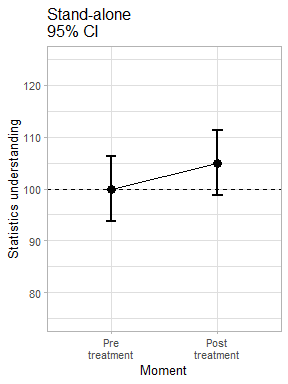

**Figure 2a**. Making left panel of Figure 2.

```r
plt2a <- superb(
            cbind(pre,post) ~ . ,
            dataFigure2,
            WSFactors    = "Moment(2)",
            adjustments  = list(purpose = "single"),
            plotStyle    = "line" )
plt2a <- plt2a + ornateWS + labs(subtitle="Stand-alone\n95% CI")
plt2a
```

… and this makes the central panel, specifying the `CA` (*correlation-adjusted*) decorelation technique:

```r
plt2b <- superb(
            cbind(pre, post) ~ . ,
            dataFigure2,
            WSFactors    = "Moment(2)",
            adjustments  = list(purpose = "difference", decorrelation = "CA"), #new
            plotStyle    = "line" )
```

```
## superb::FYI: The average correlation per group is  0.8366
```

```r
plt2b <- plt2b + ornateWS + labs(subtitle="Correlation and difference-\nadjusted 95% CI")
plt2b
```

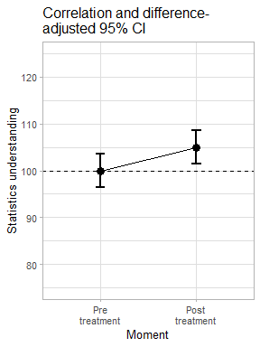

**Figure 2b**. Making central panel of Figure 2.

As seen, `superbPlot` issues relevant information (indicated with `FYI` messages), here the correlation.

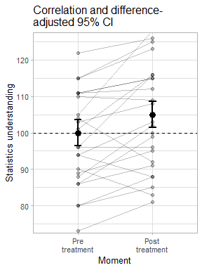

**Figure 2c**. Making third panel of Figure 2.

```r
plt2c <- superb(
            cbind(pre, post) ~ .,
            dataFigure2,
            WSFactors    = "Moment(2)",
            adjustments  = list(purpose = "difference", decorrelation = "CA"),
            plotStyle    = "pointindividualline" )   #new
plt2c <- plt2c + ornateWS + labs(subtitle="Correlation and difference-\nadjusted 95% CI")
plt2c
```

Just for the exercice, we also compute the plot of the difference between the scores. To that end, we need different labels on the x-axis and a different range:

```r
ornateWS2 <- list(
    xlab("Difference"),
    scale_x_discrete(labels=c("Post minus Pre\ntreatment")),
    ylab("Statistics understanding"),
    coord_cartesian( ylim = c(-25,+25) ),
    geom_hline(yintercept = 0, colour = "black", linewidth = 0.5, linetype=2),
    theme_light(base_size = 10) +
    theme( plot.subtitle = element_text(size=12))
)
```

We then compute the differences and make the plot:

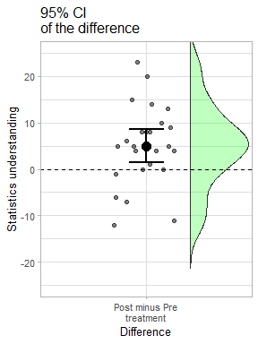

**Figure 2d**. Making right panel of Figure 2.

```r
dataFigure2$diff <- dataFigure2$post - dataFigure2$pre
plt2d <- superb(
            diff ~ .,
            dataFigure2,
            WSFactor     = "Moment(1)",
            adjustments  = list(purpose = "single", decorrelation = "none"),
            plotStyle    = "raincloud",
            violinParams = list(fill = "green") )  #new
plt2d <- plt2d + ornateWS2 + labs(subtitle="95% CI \nof the difference")
plt2d
```

This last plot does not require decorrelation and is not adjusted for difference. Decorrelation would not do anything as `diff` is a single column; difference-adjustment is inadequate here as the difference is to be compared to a fix value (namely 0, for zero improvement)

Assembling all four panels, we get:

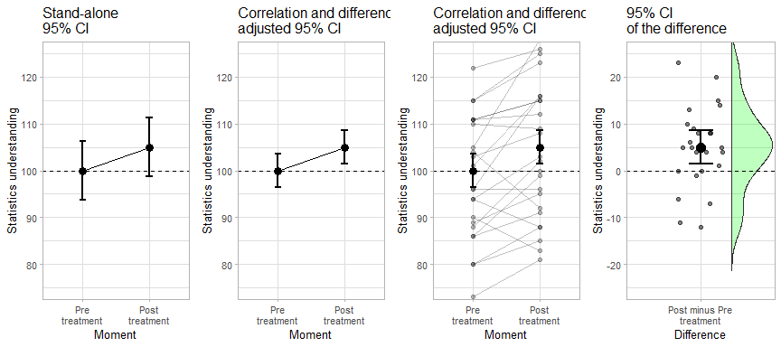

**Figure 2**. The complete Figure 2.

```r
grid.arrange(plt2a, plt2b, plt2c, plt2d,  ncol=4)
```

… which can be exported to a file as usual:

```r
png(filename = "Figure2.png", width = 850, height = 320)
grid.arrange(plt2a, plt2b, plt2c, plt2d,  ncol=4)
dev.off()
```

Which error bars are depicting the significance of the result most aptly? The adjusted ones seen in the central panel, as confirmed by a t-test on paired data:

```r
t.test(dataFigure2$pre, dataFigure2$post, paired=TRUE)
```

```
##
##  Paired t-test
##
## data:  dataFigure2$pre and dataFigure2$post
## t = -2.9046, df = 24, p-value = 0.007776
## alternative hypothesis: true mean difference is not equal to 0
## 95 percent confidence interval:
##  -8.552864 -1.447136
## sample estimates:
## mean difference
##              -5
```

The confidence interval of one moment does not *include* the result from the other moment, indicating a significant difference between the two moments.

# Making Figure 3

The novel element in Figure 3 is the fact that the participants have been recruited by clusters of participants.

We first adapt the ornaments for this example:

```r
ornateCRS <- list(
    xlab("Group"),
    ylab("Quality of policies"),
    scale_x_discrete(labels=c("From various\nfields", "From the\nsame field")), #new!
    coord_cartesian( ylim = c(75,125) ),
    geom_hline(yintercept = 100, colour = "black", linewidth = 0.5, linetype=2),
    theme_light(base_size = 10) +
    theme( plot.subtitle = element_text(size=12))
)
```

Then, we get an unadjusted plot as usual:

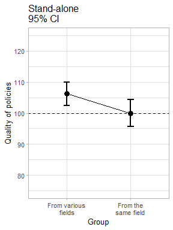

**Figure 3a**. The left panel of Figure 3.

```r
plt3a <- superb(
    VD ~ grp,
    dataFigure3,
    adjustments   = list(purpose = "single", samplingDesign = "SRS"),
    plotStyle     = "line" )
plt3a <- plt3a + ornateCRS + labs(subtitle="Stand-alone\n95% CI")
plt3a
```

Here, the option `samplingDesign = "SRS"` is the default and can be omitted.

To indicate the presence of *cluster-randomized sampling*, the `samplingDesign` option is set to `"CRS"` and an additional information, `clusterColumn` is indicated to identify the column containing the cluster membership information:

```r
plt3b <- superb(
    VD ~ grp,
    dataFigure3,
    adjustments   = list(purpose = "difference", samplingDesign = "CRS"), #new
    plotStyle     = "line",
    clusterColumn = "cluster" )                                           #new
```

```
## superb::FYI: The ICC1 per group are  0.491 0.204
```

```r
plt3b <- plt3b + ornateCRS + labs(subtitle="Cluster and difference-\nadjusted 95% CI")
plt3b
```

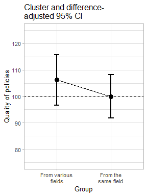

**Figure 3b**. The central panel of Figure 3.

An inspection of the distribution does not make the cluster structure evident and therefore a raincloud plot is maybe little informative in the context of cluster randomized sampling…

```r
plt3c <- superb(
    VD ~ grp,
    dataFigure3,
    adjustments   = list(purpose = "difference", samplingDesign = "CRS"),
    plotStyle     = "raincloud",
    violinParams  = list(fill = "green", alpha = 0.2),
    clusterColumn = "cluster" )
plt3c <- plt3c + ornateCRS + labs(subtitle="Cluster and difference-\nadjusted 95% CI")
```

Here is the complete Figure 3:

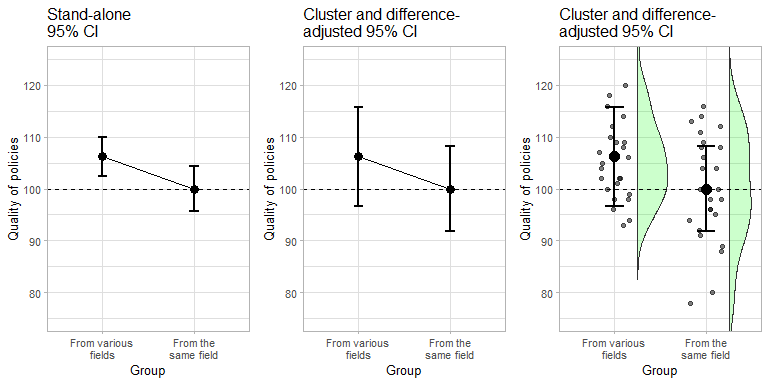

**Figure 3**. The complete Figure 3.

```r
grid.arrange(plt3a, plt3b, plt3c, ncol=3)
```

This figure is saved as before with

```r
png(filename = "Figure3.png", width = 640, height = 320)
grid.arrange(plt3a, plt3b, plt3c, ncol=3)
dev.off()
```

To make the correct *t* test in the present case, we need a correction factor called $\lambda$. An easy way is the following (see Cousineau & Laurencelle, 2016 for more)

```r
res    <- t.test( dataFigure3$VD[dataFigure3$grp==1],
                  dataFigure3$VD[dataFigure3$grp==2],
                )
# mean ICCs per group, as given by superbPlot
micc   <- mean(c(0.491335, 0.203857))
# lambda from five clusters of 5 participants each
lambda <- CousineauLaurencelleLambda(c(micc, 5, 5, 5, 5, 5, 5))
tcorrected  <- res$statistic / lambda
pcorrected  <- 1 - pt(tcorrected, 4)

cat(paste("t-test corrected for cluster-randomized sampling: t(",
    2*(dim(dataFigure3)[1]-2),") = ", round(tcorrected, 3),
    ", p = ", round(pcorrected, 3),"\n", sep= ""))
```

```
## t-test corrected for cluster-randomized sampling: t(96) = 1.419, p = 0.114
```

As seen, the proper test is returning a coherent decision with the proper error bars.

# Making Figure 4

Figure 4 is an illustration of the impact of sampling among a finite population.

```r
ornateBS <- list(
    xlab(""),
    ylab("Metabolic score"),
    scale_x_discrete(labels=c("Response to treatment")), #new!
    coord_cartesian( ylim = c(75,125) ),
    geom_hline(yintercept = 100, colour = "black", linewidth = 0.5, linetype=2),
    theme_light(base_size = 10) +
    theme( plot.subtitle = element_text(size=12))
)
```

Lets do Figure 4 (see below for each plot in a single figure).

```r
plt4a <- superb(
    score ~ group,
    dataFigure4,
    adjustments=list(purpose = "single", popSize = Inf),
    plotStyle="line" )
plt4a <- plt4a + ornateBS + labs(subtitle="Stand-alone\n95% CI")
```

The option `popSize = Inf` is the default; it indicates that the population is presumed of infinite size. A finite size can be given, as

```r
plt4b <- superb(
    score ~ group,
    dataFigure4,
    adjustments=list(purpose = "single", popSize = 50 ), # new!
    plotStyle="line" )
plt4b <- plt4b + ornateBS + labs(subtitle="Population size-\nadjusted 95% CI")
```

We illustrate the plot along some distribution information with a violin plot:

```r
plt4c <- superb(
    score ~ group,
    dataFigure4,
    adjustments=list(purpose = "single", popSize = 50 ), # new!
    plotStyle="pointjitterviolin",
    violinParams = list(fill = "green", alpha = 0.2)  )
plt4c <- plt4c + ornateBS + labs(subtitle="Population size-\nadjusted 95% CI")
```

Which are reunited as usual:

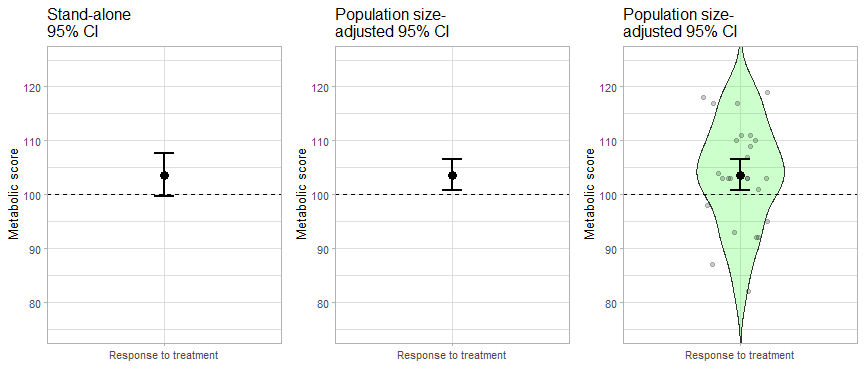

**Figure 4**. The complete Figure 4.

```r
plt4 <- grid.arrange(plt4a, plt4b, plt4c, ncol=3)
```

…and saved with:

```r
png(filename = "Figure4.png", width = 640, height = 320)
grid.arrange(plt4a, plt4b, plt4c, ncol=3)
dev.off()
```

The corrected *t* test, performed by adjusting for the proportion of the population examined (see Thompson, 2012), confirms the presence of a significant difference:

```r
res <- t.test(dataFigure4$score, mu=100)
tcorrected <- res$statistic /sqrt(1-nrow(dataFigure4) / 50)
pcorrected <- 1-pt(tcorrected, 24)

cat(paste("t-test corrected for finite-population size: t(",
    nrow(dataFigure4)-1,") = ", round(tcorrected, 3),
    ", p = ", round(pcorrected, 3),"\n", sep= ""))
```

```
## t-test corrected for finite-population size: t(24) = 2.644, p = 0.007
```

# References

Cousineau, D., Goulet, M.-A., & Harding, B. (2021). Summary plots with adjusted error bars: The superb framework with an implementation in R. *Advances in Methods and Practices in Psychological Science*, *4*, 1–18. https://doi.org/10.1177/25152459211035109

Cousineau, D., & Laurencelle, L. (2016). A correction factor for the impact of cluster randomized sampling and its applications. *Psychological Methods*, *21*, 121–135. https://doi.org/10.1037/met0000055

Delacre, M., Lakens, D., & Leys, C. (2017). Why psychologists should by default use welch’s t-test instead of student’s t-test. *International Review of Social Psychology*, *30*(1). https://doi.org/10.5334/irsp.82

Thompson, S. K. (2012). *Sampling*. New York: Wiley.